# Project 1: Deaths from Measles and Whooping Cough in London

## Adaylin Alvarez aa77336

#### 0. Introduction:

- Write a narrative introductory paragraph or two describing the datasets you have chosen, the variables they contain, how they were acquired, and why they are interesting to you. Expand on potential associations you may expect, if any.

```r
library(DAAG)
library(dplyr)
library(ggplot2)

glimpse(whoops)
```

```
##  Time-Series [1:142, 1:3] from 1740 to 1881: 280 100 122 92 46 135 95 151 150 82 ...
##  - attr(*, "dimnames")=List of 2
##   ..$ : NULL
##   ..$ : chr [1:3] "wcough" "ratio" "alldeaths"
```

```r
glimpse(poxetc)
```

```
##  Time-Series [1:253, 1:5] from 1629 to 1881: 72 40 58 531 72 ...
##  - attr(*, "dimnames")=List of 2
##   ..$ : NULL
##   ..$ : chr [1:5] "fpox" "measles" "all" "fpox2all" ...
```

*As a freshman at UT, I worked in an antibiotics laboratory where we conducted research, mainly, on Streptomyces bacteria and a few viruses. The goal of our research was to determine the reasons behind the increased resistance in bacteria against antibiotics and the resistance in viruses against antiviral medication. Due to my past experience in working with both bacteria and viruses as well as my interest in microbiology, I narrowed down my project to examine and compare three of the most infamous bacterial - whooping cough - and viral - measles and smallpox - diseases. Both the `whoops` and `poxetc` datasets examine cases of deaths relating to whooping cough, smallpox, and measles in London. The `whoops` dataset examines deaths from whooping cough, in London from 1740 to 1881, by documenting deaths caused by whooping cough, all deaths, and the ratio between the two within the time frame. The `poxetc` dataset examines deaths relating to smallpox and measles, in London from 1629 to 1881, by documenting deaths caused by smallpox and measles along with deaths from all causes and the ratio between smallpx and all deaths and measles and all deaths within the time frame.*

#### 1. Tidying: Rearranging Wide/Long (10 pts): Tidy the datasets (using the `tidyr` functions `pivot_longer`/`gather` and/or `pivot_wider`/`spread`). If you data sets are already tidy, be sure to use those functions somewhere else in your project (e.g., for rearranging summary statistics). Document the process (describe in words what was done).

```r
library(tidyverse)
library(tibble)
library(lubridate)
library(ggplot2)

poxetc <- poxetc %>% as.data.frame() %>% mutate(date = 1629:1881) %>%
    rename(smpox = fpox, smpox2all = fpox2all, alldeaths = all)
whoops <- whoops %>% as.data.frame() %>% mutate(date = 1740:1881) %>%
    rename(wcough2all = ratio)

glimpse(poxetc)
```

```
## Rows: 253
## Columns: 6
## $ smpox       <dbl> 72, 40, 58, 531, 72, 1354, 293, 127, NA, NA, NA, NA, NA, …
## $ measles     <dbl> 42, 2, 3, 80, 21, 33, 27, 12, NA, NA, NA, NA, NA, NA, NA,…
## $ alldeaths   <dbl> 8814, 10471, 8458, 9539, 8427, 10865, 10641, 23382, NA, N…
## $ smpox2all   <dbl> 8.17, 3.82, 6.85, 55.66, 8.54, 124.62, 27.53, 5.48, NA, N…
## $ measles2all <dbl> 4.47, 0.19, 0.35, 8.38, 2.49, 3.03, 2.53, 0.51, NA, NA, N…
## $ date        <int> 1629, 1630, 1631, 1632, 1633, 1634, 1635, 1636, 1637, 163…
```

```r
glimpse(whoops)
```

```
## Rows: 142
## Columns: 4
## $ wcough     <dbl> 280, 100, 122, 92, 46, 135, 95, 151, 150, 82, 55, 275, 188…
## $ wcough2all <dbl> 9.09, 3.10, 4.48, 3.07, 2.23, 6.34, 3.37, 5.92, 6.29, 3.21…
## $ alldeaths  <dbl> 30811, 32169, 27483, 25200, 20606, 21296, 28157, 25494, 23…
## $ date       <int> 1740, 1741, 1742, 1743, 1744, 1745, 1746, 1747, 1748, 1749…
```

```r
poxetc_2 <- poxetc %>% unite(measles, measles2all, col = "measles/measles2all",
    sep = "/")
poxetc_3 <- poxetc_2 %>% unite(smpox, smpox2all, col = "smpox/smpox2all",
    sep = "/")

tidypox <- poxetc_3 %>% pivot_longer(contains("/")) %>% separate(value,
    into = c("cases", "ratio2all"), sep = "/") %>% separate(name,
    into = c("disease", "ratiodisease")) %>% pivot_wider(names_from = "disease",
    values_from = "cases") %>% pivot_wider(names_from = "ratiodisease",
    values_from = "ratio2all") %>% group_by(date) %>% summarise_all(funs(toString(na.omit(.)))) %>%
    separate(alldeaths, c("alldeaths", NA), sep = ", ")



whoops_2 <- whoops %>% unite(wcough, wcough2all, col = "whoops/whoops2all",
    sep = "/")
tidywhoops <- whoops_2 %>% pivot_longer(contains("/")) %>% separate(value,
    into = c("wcough", "wcough2all"), sep = "/") %>% select(-name)

glimpse(tidypox)
```

```
## Rows: 253
## Columns: 6
## $ date        <int> 1629, 1630, 1631, 1632, 1633, 1634, 1635, 1636, 1637, 163…
## $ alldeaths   <chr> "8814", "10471", "8458", "9539", "8427", "10865", "10641"…
## $ smpox       <chr> "72", "40", "58", "531", "72", "1354", "293", "127", "NA"…
## $ measles     <chr> "42", "2", "3", "80", "21", "33", "27", "12", "NA", "NA",…
## $ smpox2all   <chr> "8.17", "3.82", "6.85", "55.66", "8.54", "124.62", "27.53…
## $ measles2all <chr> "4.47", "0.19", "0.35", "8.38", "2.49", "3.03", "2.53", "…
```

```r
glimpse(tidywhoops)
```

```
## Rows: 142
## Columns: 4
## $ alldeaths  <dbl> 30811, 32169, 27483, 25200, 20606, 21296, 28157, 25494, 23…
## $ date       <int> 1740, 1741, 1742, 1743, 1744, 1745, 1746, 1747, 1748, 1749…
## $ wcough     <chr> "280", "100", "122", "92", "46", "135", "95", "151", "150"…
## $ wcough2all <chr> "9.09", "3.1", "4.48", "3.07", "2.23", "6.34", "3.37", "5.…
```

#### 2. Joining/Merging (10 pts):

- Join your datasets into one using a `dplyr` join function
- If you have multiple observations on the joining variable in either dataset, fix this by collapsing via summarize
- Discuss the process in words, including why you chose the join you did
- Discuss which cases were dropped, if any, and potential problems with this

```r
diseases_messy <- inner_join(whoops, poxetc, by = c(date = "date")) %>%
    select(-alldeaths.x) %>% rename(alldeaths = alldeaths.y)

diseases <- diseases_messy[, c(3, 1, 4, 5, 2, 7, 8, 6)]

diseases %>% nrow()
```

```
## [1] 142
```

```r
diseases %>% summarise_all(funs(sum(is.na(.))))
```

```
##   date wcough smpox measles wcough2all smpox2all measles2all alldeaths
## 1    0      0     9       9          0         9           9         9
```

```r
diseases %>% tidyr::drop_na() %>% nrow()
```

```
## [1] 133
```

```r
diseases <- diseases %>% tidyr::drop_na()
diseases
```

```
##    date wcough smpox measles wcough2all smpox2all measles2all alldeaths
## 1  1740    280  2725      46       9.09     88.44        1.48     30811
## 2  1741    100  1977      42       3.10     61.45        1.30     32169
## 3  1742    122  1429     981       4.48     51.99       35.69     27483
## 4  1743     92  2029      17       3.07     80.51        0.67     25200
## 5  1744     46  1633       5       2.23     79.24        0.24     20606
## 6  1745    135  1206      14       6.34     56.63        0.65     21296
## 7  1746     95  3236     250       3.37    114.92        8.87     28157
## 8  1747    151  1380      81       5.92     54.13        3.17     25494
## 9  1748    150  1789      10       6.29     74.95        0.41     23869
## 10 1749     82  2625     106       3.21    102.87        4.15     25516
## 11 1750     55  1229     321       2.32     52.64       13.52     23727
## 12 1751    275   998      21      13.08     47.46        0.99     21028
##  [ reached 'max' / getOption("max.print") -- omitted 121 rows ]
```

#### 3. Wrangling (40 pts):

- Use all six core `dplyr` functions in the service of generating summary tables/statistics (12 pts)
  - Use mutate at least once to generate a variable that is a function of at least one other variable
- Compute summary statistics for each of your variables using `summarize` alone and with `group_by` (if you have more than 10 variables, fine to just focus on 10) (20 pts)
  - Use at least 5 unique functions inside of summarize (e.g., mean, sd)
  - For at least 2, use summarize after grouping by a categorical variable. Create one by dichotomizing a numeric if necessary
  - If applicable, at least 1 of these should group by two categorical variables
- Summarize the procedure and discuss all (or the most interesting) results in no more than two paragraphs (8 pts)

```r
diseases <- diseases %>% mutate(sumcases = wcough + smpox + measles)
diseases <- diseases[, c(1, 2, 3, 4, 9, 5, 6, 7, 8)]


acc_diseases <- diseases %>% mutate(cases2all = sumcases/alldeaths *
    100)
acc_diseases <- acc_diseases[, c(1, 2, 3, 4, 5, 6, 7, 8, 10,
    9)]


acc_diseases <- acc_diseases %>% mutate(wcough2all = wcough2all/10)
acc_diseases <- acc_diseases %>% mutate(smpox2all = smpox2all/10)
acc_diseases <- acc_diseases %>% mutate(measles2all = measles2all/10)
acc_diseases <- acc_diseases %>% mutate(cases2all = round(cases2all,
    3))


acc_diseases %>% filter(date <= median(date)) %>% select(date,
    wcough, smpox, measles, alldeaths) %>% arrange(desc(alldeaths))
```

```
##    date wcough smpox measles alldeaths
## 1  1741    100  1977      42     32169
## 2  1740    280  2725      46     30811
## 3  1746     95  3236     250     28157
## 4  1742    122  1429     981     27483
## 5  1762    300  2743     122     26326
## 6  1763    291  3582     610     26148
## 7  1772    385  3992     211     26053
## 8  1749     82  2625     106     25516
## 9  1747    151  1380      81     25494
## 10 1743     92  2029      17     25200
## 11 1766    213  2334     482     23911
## 12 1748    150  1789      10     23869
## 13 1750     55  1229     321     23727
## 14 1768    262  3028     409     23639
## 15 1777    536  2567     145     23334
## 16 1765    225  2498      54     23230
## 17 1764    251  2382      65     23202
## 18 1800    380  2409     395     23068
## 19 1754    336  2359      12     22696
## 20 1767    364  2188      80     22612
##  [ reached 'max' / getOption("max.print") -- omitted 47 rows ]
```

```r
acc_diseases <- acc_diseases %>% mutate(time.period = case_when(date >
    1834 ~ "late", date <= 1834 & 1787 <= date ~ "mid", date <
    1787 ~ "early"))
acc_diseases %>% group_by(time.period) %>% summarize(count = n()) %>%
    head(3)
```

```
## # A tibble: 3 x 2
##   time.period count
##   <chr>       <int>
## 1 early          47
## 2 late           41
## 3 mid            45
```

```r
acc_diseases %>% group_by(time.period) %>% summarize(mean_wcough = mean(wcough,
    na.rm = T), sd_wcough = sd(wcough, na.rm = T))
```

```
## # A tibble: 3 x 3
##   time.period mean_wcough sd_wcough
##   <chr>             <dbl>     <dbl>
## 1 early              235.      131.
## 2 late              2012.     1171.
## 3 mid                577.      255.
```

```r
acc_diseases %>% group_by(time.period) %>% summarize(mean_smpox = mean(smpox,
    na.rm = T), sd_smpox = sd(smpox, na.rm = T))
```

```
## # A tibble: 3 x 3
##   time.period mean_smpox sd_smpox
##   <chr>            <dbl>    <dbl>
## 1 early            2078.     805.
## 2 late             1020.    1269.
## 3 mid              1196.     672.
```

```r
acc_diseases %>% group_by(time.period) %>% summarize(mean_measles = mean(measles,
    na.rm = T), sd_measles = sd(measles, na.rm = T))
```

```
## # A tibble: 3 x 3
##   time.period mean_measles sd_measles
##   <chr>              <dbl>      <dbl>
## 1 early               214.       217.
## 2 late               1575        537.
## 3 mid                 519.       294.
```

```r
acc_diseases %>% filter(time.period == "early") %>% select(date,
    alldeaths) %>% arrange(desc(alldeaths))
```

```
##    date alldeaths
## 1  1741     32169
## 2  1740     30811
## 3  1746     28157
## 4  1742     27483
## 5  1762     26326
## 6  1763     26148
## 7  1772     26053
## 8  1749     25516
## 9  1747     25494
## 10 1743     25200
## 11 1766     23911
## 12 1748     23869
## 13 1750     23727
## 14 1768     23639
```

[output cut: 33 more lines]

```r
acc_diseases %>% filter(time.period == "mid") %>% select(date,
    alldeaths) %>% arrange(desc(alldeaths))
```

```
##    date alldeaths
## 1  1831     25337
## 2  1829     23524
## 3  1800     23068
## 4  1827     22292
## 5  1793     21749
## 6  1828     21709
## 7  1830     21645
## 8  1795     21179
## 9  1825     21026
## 10 1826     20758
## 11 1789     20749
## 12 1823     20587
## 13 1816     20316
## 14 1824     20237
```

[output cut: 31 more lines]

```r
acc_diseases %>% filter(time.period == "late") %>% select(date,
    alldeaths) %>% arrange(desc(alldeaths))
```

```
##    date alldeaths
## 1  1878     84188
## 2  1879     83805
## 3  1875     81964
## 4  1880     81128
## 5  1881     81071
## 6  1866     80453
## 7  1871     80430
## 8  1864     78238
## 9  1869     78082
## 10 1876     77671
## 11 1870     77634
## 12 1877     77449
## 13 1874     76813
## 14 1873     75459
```

[output cut: 27 more lines]

```r
acc_diseases %>% group_by(time.period) %>% summarize(min_alldeaths = min(alldeaths,
    na.rm = T))
```

```
## # A tibble: 3 x 2
##   time.period min_alldeaths
##   <chr>               <dbl>
## 1 early               17576
## 2 late                45400
## 3 mid                 16680
```

```r
acc_diseases %>% group_by(time.period) %>% summarize(max_alldeaths = max(alldeaths,
    na.rm = T))
```

```
## # A tibble: 3 x 2
##   time.period max_alldeaths
##   <chr>               <dbl>
## 1 early               32169
## 2 late                84188
## 3 mid                 25337
```

```r
acc_diseases %>% group_by(time.period) %>% summarize(med_alldeaths = median(alldeaths,
    na.rm = T))
```

```
## # A tibble: 3 x 2
##   time.period med_alldeaths
##   <chr>               <dbl>
## 1 early               21656
## 2 late                68755
## 3 mid                 19379
```

#### 4.Visualizing (30 pts):

- Create a correlation heatmap of your numeric variables the way we did in class
- Create two more effective, polished plots with ggplot
  - Each plot should map 3+ variables to aesthetics
  - Each plot should have a title and clean labeling for all mappings
  - Change at least one default theme element and color for at least one mapping per plot
  - For at least one plot, add more tick marks (x, y, or both) than are given by default
  - For at least one plot, use the stat=“summary” function
  - Supporting paragraph or two (for each plot) describing the relationships/trends that are apparent

```r
cormat <- acc_diseases %>% select_if(is.numeric) %>% cor(use = "pair")
cormat <- cormat %>% round(2)
cormat
```

```
##              date wcough smpox measles sumcases wcough2all smpox2all
## date         1.00   0.66 -0.42    0.84     0.50       0.52     -0.73
## wcough       0.66   1.00 -0.20    0.57     0.76       0.71     -0.52
## smpox       -0.42  -0.20  1.00   -0.34     0.39      -0.28      0.75
## measles      0.84   0.57 -0.34    1.00     0.58       0.28     -0.67
## sumcases     0.50   0.76  0.39    0.58     1.00       0.39     -0.13
## wcough2all   0.52   0.71 -0.28    0.28     0.39       1.00     -0.39
## smpox2all   -0.73  -0.52  0.75   -0.67    -0.13      -0.39      1.00
## measles2all  0.45   0.22 -0.38    0.58     0.14       0.38     -0.43
## cases2all   -0.47  -0.19  0.66   -0.44     0.13       0.09      0.79
## alldeaths    0.81   0.63 -0.19    0.84     0.64       0.17     -0.61
##             measles2all cases2all alldeaths
## date               0.45     -0.47      0.81
## wcough             0.22     -0.19      0.63
## smpox             -0.38      0.66     -0.19
## measles            0.58     -0.44      0.84
## sumcases           0.14      0.13      0.64
## wcough2all         0.38      0.09      0.17
## smpox2all         -0.43      0.79     -0.61
## measles2all        1.00     -0.03      0.16
## cases2all         -0.03      1.00     -0.58
## alldeaths          0.16     -0.58      1.00
```

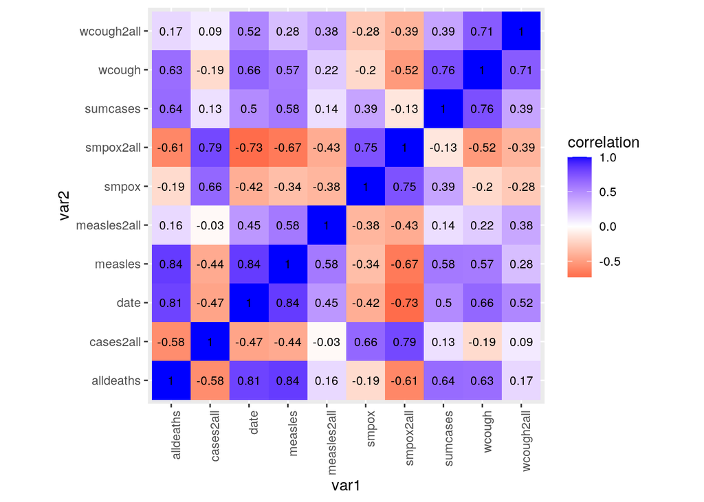

```r
tidycor <- cormat %>% as.data.frame %>% rownames_to_column("var1") %>%
    pivot_longer(-1, names_to = "var2", values_to = "correlation")
tidycor %>% ggplot(aes(var1, var2, fill = correlation)) + geom_tile() +
    scale_fill_gradient2(low = "red", mid = "white", high = "blue") +
    geom_text(aes(label = round(correlation, 2)), color = "black",
        size = 3) + coord_fixed() + theme(axis.text.x = element_text(angle = 90,
    hjust = 1))
```

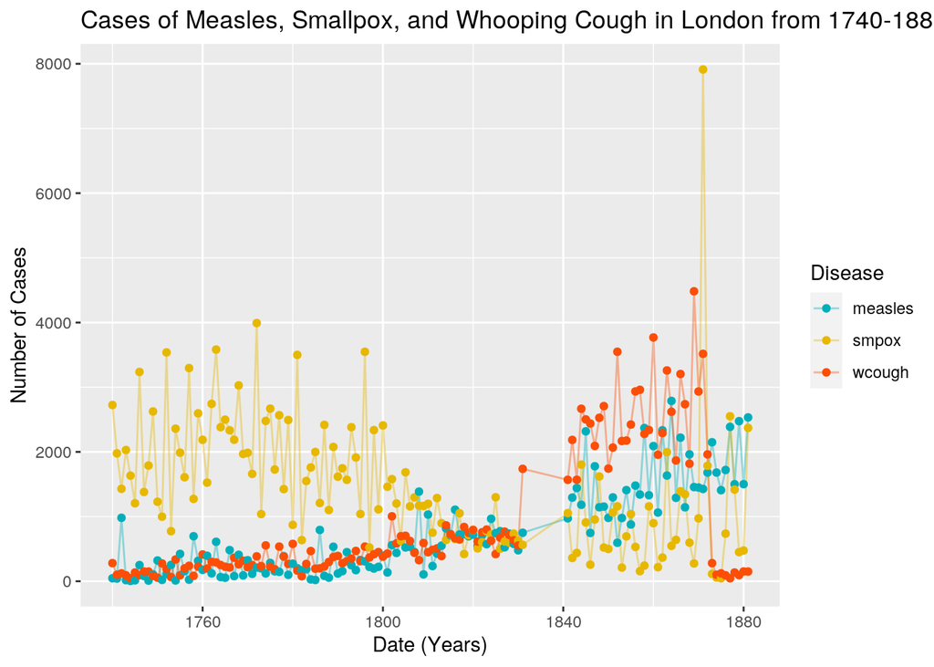

```r
trial <- acc_diseases %>% pivot_longer(c("measles", "smpox",
    "wcough"), names_to = "disease_type", values_to = "cases")


plot1 <- ggplot(trial, aes(x = date, y = cases, color = disease_type)) +
    geom_line(alpha = 0.4) + geom_point() + scale_color_manual(values = c("#00AFBB",
    "#E7B800", "#FC4E07")) + ggtitle("Cases of Measles, Smallpox, and Whooping Cough in London from 1740-1881") +
    ylab("Number of Cases") + xlab("Date (Years)")
plot1 <- update_labels(plot1, list(colour = "Disease"))



plot2 <- plot1 + facet_wrap(~disease_type) + scale_x_continuous(breaks = scales::pretty_breaks(n = 8)) +
    scale_y_continuous(breaks = scales::pretty_breaks(n = 8)) +
    theme(axis.text.x = element_text(angle = 90, hjust = 1)) +
    theme(legend.position = "none")



plot3 <- ggplot(trial, aes(x = date, y = cases, color = disease_type)) +
    geom_point() + scale_colour_brewer(palette = "Set1") + geom_line(color = "black",
    aes(y = cases), stat = "summary", fun = mean) + ggtitle("Avg Number of Cases of Measles, Smallpox, and Whooping Cough from 1740-1881") +
    ylab("Number of Cases") + xlab("Date (Years)")
plot3 <- update_labels(plot3, list(colour = "Disease"))

plot1
```